# Risk Factor Analysis

## Outcome Variable

**Outcome Variable:** ever_stunted

## Predictor Variables

**Intervention Variable:** birthlen

**Adjustment Set:**

unadjusted

## Stratifying Variables

The analysis was stratified on these variable(s):

- agecat
- studyid
- country

## Data Summary

| agecat | studyid | country | birthlen | ever_stunted | n_cell | n |
| --- | --- | --- | --- | --- | --- | --- |
| 0-6 months | ki0047075b-MAL-ED | BANGLADESH | >=0 | 0 | 39 | 257 |
| 0-6 months | ki0047075b-MAL-ED | BANGLADESH | >=0 | 1 | 0 | 257 |
| 0-6 months | ki0047075b-MAL-ED | BANGLADESH | <-3 | 0 | 0 | 257 |
| 0-6 months | ki0047075b-MAL-ED | BANGLADESH | <-3 | 1 | 9 | 257 |
| 0-6 months | ki0047075b-MAL-ED | BANGLADESH | [-3–2) | 0 | 0 | 257 |
| 0-6 months | ki0047075b-MAL-ED | BANGLADESH | [-3–2) | 1 | 38 | 257 |
| 0-6 months | ki0047075b-MAL-ED | BANGLADESH | [-2–1) | 0 | 83 | 257 |
| 0-6 months | ki0047075b-MAL-ED | BANGLADESH | [-2–1) | 1 | 0 | 257 |
| 0-6 months | ki0047075b-MAL-ED | BANGLADESH | [-1-0) | 0 | 88 | 257 |
| 0-6 months | ki0047075b-MAL-ED | BANGLADESH | [-1-0) | 1 | 0 | 257 |
| 0-6 months | ki0047075b-MAL-ED | BRAZIL | >=0 | 0 | 44 | 191 |
| 0-6 months | ki0047075b-MAL-ED | BRAZIL | >=0 | 1 | 0 | 191 |
| 0-6 months | ki0047075b-MAL-ED | BRAZIL | <-3 | 0 | 0 | 191 |
| 0-6 months | ki0047075b-MAL-ED | BRAZIL | <-3 | 1 | 8 | 191 |
| 0-6 months | ki0047075b-MAL-ED | BRAZIL | [-3–2) | 0 | 0 | 191 |
| 0-6 months | ki0047075b-MAL-ED | BRAZIL | [-3–2) | 1 | 13 | 191 |
| 0-6 months | ki0047075b-MAL-ED | BRAZIL | [-2–1) | 0 | 48 | 191 |
| 0-6 months | ki0047075b-MAL-ED | BRAZIL | [-2–1) | 1 | 0 | 191 |
| 0-6 months | ki0047075b-MAL-ED | BRAZIL | [-1-0) | 0 | 78 | 191 |
| 0-6 months | ki0047075b-MAL-ED | BRAZIL | [-1-0) | 1 | 0 | 191 |
| 0-6 months | ki0047075b-MAL-ED | INDIA | >=0 | 0 | 34 | 206 |
| 0-6 months | ki0047075b-MAL-ED | INDIA | >=0 | 1 | 0 | 206 |
| 0-6 months | ki0047075b-MAL-ED | INDIA | <-3 | 0 | 0 | 206 |
| 0-6 months | ki0047075b-MAL-ED | INDIA | <-3 | 1 | 7 | 206 |
| 0-6 months | ki0047075b-MAL-ED | INDIA | [-3–2) | 0 | 0 | 206 |
| 0-6 months | ki0047075b-MAL-ED | INDIA | [-3–2) | 1 | 26 | 206 |
| 0-6 months | ki0047075b-MAL-ED | INDIA | [-2–1) | 0 | 66 | 206 |
| 0-6 months | ki0047075b-MAL-ED | INDIA | [-2–1) | 1 | 0 | 206 |
| 0-6 months | ki0047075b-MAL-ED | INDIA | [-1-0) | 0 | 73 | 206 |
| 0-6 months | ki0047075b-MAL-ED | INDIA | [-1-0) | 1 | 0 | 206 |

[output cut: 668 more lines]

The following strata were considered:

- agecat: 0-24 months, studyid: ki0047075b-MAL-ED, country: BANGLADESH
- agecat: 0-24 months, studyid: ki0047075b-MAL-ED, country: BRAZIL
- agecat: 0-24 months, studyid: ki0047075b-MAL-ED, country: INDIA
- agecat: 0-24 months, studyid: ki0047075b-MAL-ED, country: NEPAL
- agecat: 0-24 months, studyid: ki0047075b-MAL-ED, country: PERU
- agecat: 0-24 months, studyid: ki0047075b-MAL-ED, country: SOUTH AFRICA
- agecat: 0-24 months, studyid: ki0047075b-MAL-ED, country: TANZANIA, UNITED REPUBLIC OF
- agecat: 0-24 months, studyid: ki1000108-CMC-V-BCS-2002, country: INDIA
- agecat: 0-24 months, studyid: ki1000108-IRC, country: INDIA
- agecat: 0-24 months, studyid: ki1000109-EE, country: PAKISTAN
- agecat: 0-24 months, studyid: ki1000109-ResPak, country: PAKISTAN
- agecat: 0-24 months, studyid: ki1000304b-SAS-CompFeed, country: INDIA
- agecat: 0-24 months, studyid: ki1017093-NIH-Birth, country: BANGLADESH
- agecat: 0-24 months, studyid: ki1017093b-PROVIDE, country: BANGLADESH
- agecat: 0-24 months, studyid: ki1017093c-NIH-Crypto, country: BANGLADESH
- agecat: 0-24 months, studyid: ki1101329-Keneba, country: GAMBIA
- agecat: 0-24 months, studyid: ki1114097-CMIN, country: BANGLADESH
- agecat: 0-24 months, studyid: ki1114097-CMIN, country: BRAZIL
- agecat: 0-24 months, studyid: ki1114097-CMIN, country: PERU
- agecat: 0-24 months, studyid: ki1114097-CONTENT, country: PERU
- agecat: 0-24 months, studyid: ki1119695-PROBIT, country: BELARUS
- agecat: 0-24 months, studyid: ki1126311-ZVITAMBO, country: ZIMBABWE
- agecat: 0-24 months, studyid: ki1135781-COHORTS, country: GUATEMALA
- agecat: 0-24 months, studyid: ki1135781-COHORTS, country: INDIA
- agecat: 0-24 months, studyid: ki1135781-COHORTS, country: PHILIPPINES
- agecat: 0-24 months, studyid: kiGH5241-JiVitA-3, country: BANGLADESH
- agecat: 0-24 months, studyid: kiGH5241-JiVitA-4, country: BANGLADESH
- agecat: 0-6 months, studyid: ki0047075b-MAL-ED, country: BANGLADESH
- agecat: 0-6 months, studyid: ki0047075b-MAL-ED, country: BRAZIL
- agecat: 0-6 months, studyid: ki0047075b-MAL-ED, country: INDIA
- agecat: 0-6 months, studyid: ki0047075b-MAL-ED, country: NEPAL
- agecat: 0-6 months, studyid: ki0047075b-MAL-ED, country: PERU
- agecat: 0-6 months, studyid: ki0047075b-MAL-ED, country: SOUTH AFRICA
- agecat: 0-6 months, studyid: ki0047075b-MAL-ED, country: TANZANIA, UNITED REPUBLIC OF
- agecat: 0-6 months, studyid: ki1000108-CMC-V-BCS-2002, country: INDIA
- agecat: 0-6 months, studyid: ki1000108-IRC, country: INDIA
- agecat: 0-6 months, studyid: ki1000109-EE, country: PAKISTAN
- agecat: 0-6 months, studyid: ki1000109-ResPak, country: PAKISTAN
- agecat: 0-6 months, studyid: ki1000304b-SAS-CompFeed, country: INDIA
- agecat: 0-6 months, studyid: ki1017093-NIH-Birth, country: BANGLADESH
- agecat: 0-6 months, studyid: ki1017093b-PROVIDE, country: BANGLADESH
- agecat: 0-6 months, studyid: ki1017093c-NIH-Crypto, country: BANGLADESH
- agecat: 0-6 months, studyid: ki1101329-Keneba, country: GAMBIA
- agecat: 0-6 months, studyid: ki1114097-CMIN, country: BANGLADESH
- agecat: 0-6 months, studyid: ki1114097-CMIN, country: BRAZIL
- agecat: 0-6 months, studyid: ki1114097-CMIN, country: PERU
- agecat: 0-6 months, studyid: ki1114097-CONTENT, country: PERU
- agecat: 0-6 months, studyid: ki1119695-PROBIT, country: BELARUS
- agecat: 0-6 months, studyid: ki1126311-ZVITAMBO, country: ZIMBABWE
- agecat: 0-6 months, studyid: ki1135781-COHORTS, country: GUATEMALA
- agecat: 0-6 months, studyid: ki1135781-COHORTS, country: INDIA
- agecat: 0-6 months, studyid: ki1135781-COHORTS, country: PHILIPPINES
- agecat: 0-6 months, studyid: kiGH5241-JiVitA-3, country: BANGLADESH
- agecat: 0-6 months, studyid: kiGH5241-JiVitA-4, country: BANGLADESH
- agecat: 6-24 months, studyid: ki0047075b-MAL-ED, country: BANGLADESH
- agecat: 6-24 months, studyid: ki0047075b-MAL-ED, country: BRAZIL
- agecat: 6-24 months, studyid: ki0047075b-MAL-ED, country: INDIA
- agecat: 6-24 months, studyid: ki0047075b-MAL-ED, country: NEPAL
- agecat: 6-24 months, studyid: ki0047075b-MAL-ED, country: PERU
- agecat: 6-24 months, studyid: ki0047075b-MAL-ED, country: SOUTH AFRICA
- agecat: 6-24 months, studyid: ki0047075b-MAL-ED, country: TANZANIA, UNITED REPUBLIC OF
- agecat: 6-24 months, studyid: ki1000108-CMC-V-BCS-2002, country: INDIA
- agecat: 6-24 months, studyid: ki1000108-IRC, country: INDIA
- agecat: 6-24 months, studyid: ki1000109-EE, country: PAKISTAN
- agecat: 6-24 months, studyid: ki1000109-ResPak, country: PAKISTAN
- agecat: 6-24 months, studyid: ki1000304b-SAS-CompFeed, country: INDIA
- agecat: 6-24 months, studyid: ki1017093-NIH-Birth, country: BANGLADESH
- agecat: 6-24 months, studyid: ki1017093b-PROVIDE, country: BANGLADESH
- agecat: 6-24 months, studyid: ki1017093c-NIH-Crypto, country: BANGLADESH
- agecat: 6-24 months, studyid: ki1101329-Keneba, country: GAMBIA
- agecat: 6-24 months, studyid: ki1114097-CMIN, country: BRAZIL
- agecat: 6-24 months, studyid: ki1114097-CMIN, country: PERU
- agecat: 6-24 months, studyid: ki1114097-CONTENT, country: PERU
- agecat: 6-24 months, studyid: ki1119695-PROBIT, country: BELARUS
- agecat: 6-24 months, studyid: ki1126311-ZVITAMBO, country: ZIMBABWE
- agecat: 6-24 months, studyid: ki1135781-COHORTS, country: GUATEMALA
- agecat: 6-24 months, studyid: ki1135781-COHORTS, country: INDIA
- agecat: 6-24 months, studyid: ki1135781-COHORTS, country: PHILIPPINES
- agecat: 6-24 months, studyid: kiGH5241-JiVitA-3, country: BANGLADESH
- agecat: 6-24 months, studyid: kiGH5241-JiVitA-4, country: BANGLADESH

### Dropped Strata

Some strata were dropped due to rare outcomes:

- agecat: 0-6 months, studyid: ki0047075b-MAL-ED, country: BANGLADESH
- agecat: 0-6 months, studyid: ki0047075b-MAL-ED, country: BRAZIL
- agecat: 0-6 months, studyid: ki0047075b-MAL-ED, country: INDIA
- agecat: 0-6 months, studyid: ki0047075b-MAL-ED, country: NEPAL
- agecat: 0-6 months, studyid: ki0047075b-MAL-ED, country: PERU
- agecat: 0-6 months, studyid: ki0047075b-MAL-ED, country: SOUTH AFRICA
- agecat: 0-6 months, studyid: ki0047075b-MAL-ED, country: TANZANIA, UNITED REPUBLIC OF
- agecat: 0-6 months, studyid: ki1000108-CMC-V-BCS-2002, country: INDIA
- agecat: 0-6 months, studyid: ki1000108-IRC, country: INDIA
- agecat: 0-6 months, studyid: ki1000109-EE, country: PAKISTAN
- agecat: 0-6 months, studyid: ki1000109-ResPak, country: PAKISTAN
- agecat: 0-6 months, studyid: ki1000304b-SAS-CompFeed, country: INDIA
- agecat: 0-6 months, studyid: ki1017093-NIH-Birth, country: BANGLADESH
- agecat: 0-6 months, studyid: ki1017093b-PROVIDE, country: BANGLADESH
- agecat: 0-6 months, studyid: ki1017093c-NIH-Crypto, country: BANGLADESH
- agecat: 0-6 months, studyid: ki1101329-Keneba, country: GAMBIA
- agecat: 0-6 months, studyid: ki1114097-CMIN, country: BANGLADESH
- agecat: 0-6 months, studyid: ki1114097-CMIN, country: BRAZIL
- agecat: 0-6 months, studyid: ki1114097-CONTENT, country: PERU
- agecat: 0-6 months, studyid: ki1119695-PROBIT, country: BELARUS
- agecat: 0-6 months, studyid: ki1126311-ZVITAMBO, country: ZIMBABWE
- agecat: 0-6 months, studyid: ki1135781-COHORTS, country: GUATEMALA
- agecat: 0-6 months, studyid: ki1135781-COHORTS, country: INDIA
- agecat: 0-6 months, studyid: ki1135781-COHORTS, country: PHILIPPINES
- agecat: 0-6 months, studyid: kiGH5241-JiVitA-3, country: BANGLADESH
- agecat: 0-6 months, studyid: kiGH5241-JiVitA-4, country: BANGLADESH
- agecat: 6-24 months, studyid: ki0047075b-MAL-ED, country: BANGLADESH
- agecat: 6-24 months, studyid: ki0047075b-MAL-ED, country: BRAZIL
- agecat: 6-24 months, studyid: ki0047075b-MAL-ED, country: INDIA
- agecat: 6-24 months, studyid: ki0047075b-MAL-ED, country: NEPAL
- agecat: 6-24 months, studyid: ki0047075b-MAL-ED, country: PERU
- agecat: 6-24 months, studyid: ki0047075b-MAL-ED, country: SOUTH AFRICA
- agecat: 6-24 months, studyid: ki0047075b-MAL-ED, country: TANZANIA, UNITED REPUBLIC OF
- agecat: 6-24 months, studyid: ki1000108-CMC-V-BCS-2002, country: INDIA
- agecat: 6-24 months, studyid: ki1000108-IRC, country: INDIA
- agecat: 6-24 months, studyid: ki1000109-EE, country: PAKISTAN
- agecat: 6-24 months, studyid: ki1000109-ResPak, country: PAKISTAN
- agecat: 6-24 months, studyid: ki1017093-NIH-Birth, country: BANGLADESH
- agecat: 6-24 months, studyid: ki1017093b-PROVIDE, country: BANGLADESH
- agecat: 6-24 months, studyid: ki1017093c-NIH-Crypto, country: BANGLADESH
- agecat: 6-24 months, studyid: ki1114097-CMIN, country: BRAZIL
- agecat: 6-24 months, studyid: ki1114097-CMIN, country: PERU
- agecat: 6-24 months, studyid: ki1114097-CONTENT, country: PERU
- agecat: 6-24 months, studyid: ki1119695-PROBIT, country: BELARUS
- agecat: 6-24 months, studyid: ki1135781-COHORTS, country: GUATEMALA
- agecat: 6-24 months, studyid: ki1135781-COHORTS, country: PHILIPPINES
- agecat: 0-24 months, studyid: ki0047075b-MAL-ED, country: BANGLADESH
- agecat: 0-24 months, studyid: ki0047075b-MAL-ED, country: BRAZIL
- agecat: 0-24 months, studyid: ki0047075b-MAL-ED, country: INDIA
- agecat: 0-24 months, studyid: ki0047075b-MAL-ED, country: NEPAL
- agecat: 0-24 months, studyid: ki0047075b-MAL-ED, country: PERU
- agecat: 0-24 months, studyid: ki0047075b-MAL-ED, country: SOUTH AFRICA
- agecat: 0-24 months, studyid: ki0047075b-MAL-ED, country: TANZANIA, UNITED REPUBLIC OF
- agecat: 0-24 months, studyid: ki1000108-CMC-V-BCS-2002, country: INDIA
- agecat: 0-24 months, studyid: ki1000108-IRC, country: INDIA
- agecat: 0-24 months, studyid: ki1000109-EE, country: PAKISTAN
- agecat: 0-24 months, studyid: ki1000109-ResPak, country: PAKISTAN
- agecat: 0-24 months, studyid: ki1000304b-SAS-CompFeed, country: INDIA
- agecat: 0-24 months, studyid: ki1017093-NIH-Birth, country: BANGLADESH
- agecat: 0-24 months, studyid: ki1017093b-PROVIDE, country: BANGLADESH
- agecat: 0-24 months, studyid: ki1017093c-NIH-Crypto, country: BANGLADESH
- agecat: 0-24 months, studyid: ki1101329-Keneba, country: GAMBIA
- agecat: 0-24 months, studyid: ki1114097-CMIN, country: BANGLADESH
- agecat: 0-24 months, studyid: ki1114097-CMIN, country: BRAZIL
- agecat: 0-24 months, studyid: ki1114097-CMIN, country: PERU
- agecat: 0-24 months, studyid: ki1114097-CONTENT, country: PERU
- agecat: 0-24 months, studyid: ki1119695-PROBIT, country: BELARUS
- agecat: 0-24 months, studyid: ki1126311-ZVITAMBO, country: ZIMBABWE
- agecat: 0-24 months, studyid: ki1135781-COHORTS, country: GUATEMALA
- agecat: 0-24 months, studyid: ki1135781-COHORTS, country: INDIA
- agecat: 0-24 months, studyid: ki1135781-COHORTS, country: PHILIPPINES
- agecat: 0-24 months, studyid: kiGH5241-JiVitA-3, country: BANGLADESH
- agecat: 0-24 months, studyid: kiGH5241-JiVitA-4, country: BANGLADESH

## Methods Detail

We’re interested in the causal parameters $E[Y_a]$ for all values of $a \in \mathcal{A}$. These parameters represent the mean outcome if, possibly contrary to fact, we intervened to set all units to have $A=a$. Under the randomization and positivity assumptions, these are identified by the statistical parameters $\psi_a=E_W[E_{Y|A,W}(Y|A=a,W)]$. In addition, we’re interested in the mean of $Y$, $E[Y]$ under no intervention (the observed mean). We will estimate these parameters by using SuperLearner to fit the relevant likelihood factors – $E_{Y|A,W}(Y|A=a,W)$ and $p(A=a|W)$, and then updating our likelihood fit using a joint TMLE.

For unadjusted analyses ($W=\{\}$), initial likelihoods were estimated using Lrnr_glm to estimate the simple $E(Y|A)$ and Lrnr_mean to estimate $p(A)$. For adjusted analyses, a small library containing Lrnr_glmnet, Lrnr_xgboost, and Lrnr_mean was used.

Having estimated these parameters, we will then use the delta method to estimate relative risks and attributable risks relative to a prespecified baseline level of $A$.

```
##          ever_stunted
## birthlen   0
##   >=0     10
##   <-3      0
##   [-3--2)  0
##   [-2--1)  0
##   [-1-0)   0
##          ever_stunted
## birthlen     0
##   >=0     1673
##   <-3       56
##   [-3--2)  253
##   [-2--1) 1050
##   [-1-0)  1990
```

# Results Detail

## Results Plots

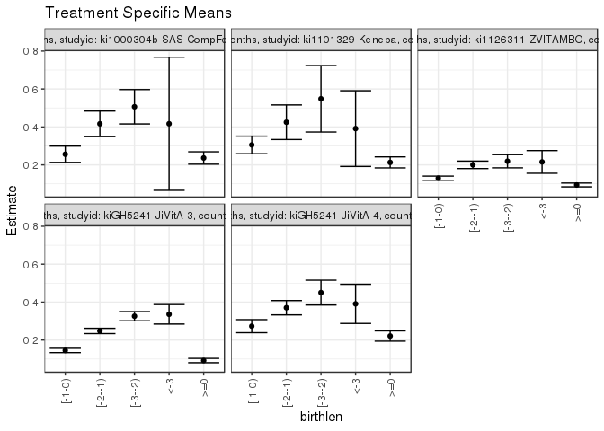

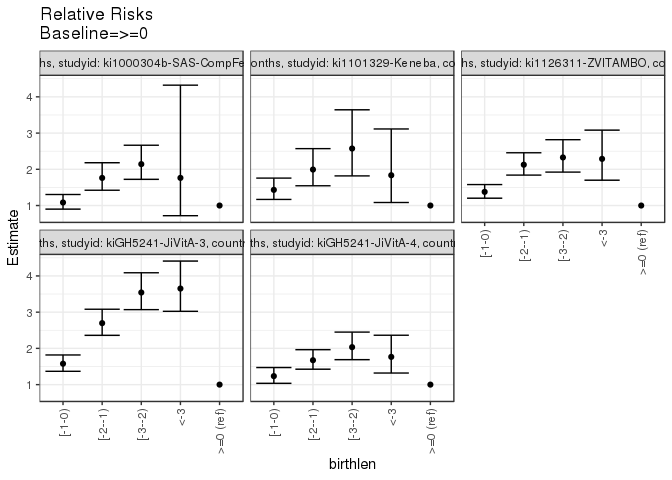

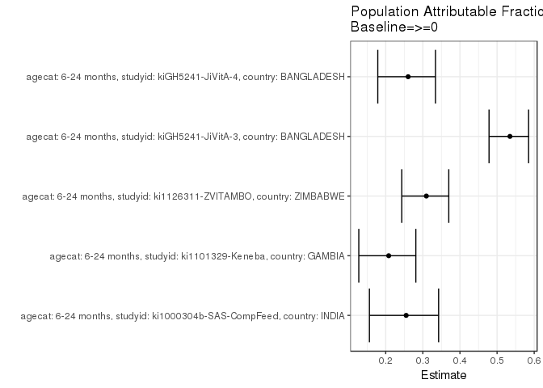

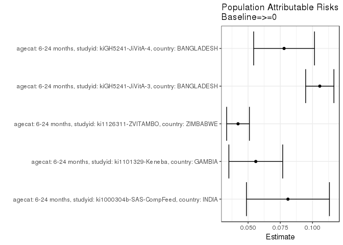

## Results Table

### Parameter: TSM

| agecat | studyid | country | intervention_level | baseline_level | estimate | ci_lower | ci_upper |
| --- | --- | --- | --- | --- | --- | --- | --- |
| 6-24 months | ki1000304b-SAS-CompFeed | INDIA | >=0 | NA | 0.2362869 | 0.2035816 | 0.2689922 |
| 6-24 months | ki1000304b-SAS-CompFeed | INDIA | <-3 | NA | 0.4166667 | 0.0656513 | 0.7676820 |
| 6-24 months | ki1000304b-SAS-CompFeed | INDIA | [-3–2) | NA | 0.5063291 | 0.4156086 | 0.5970496 |
| 6-24 months | ki1000304b-SAS-CompFeed | INDIA | [-2–1) | NA | 0.4163424 | 0.3489604 | 0.4837244 |
| 6-24 months | ki1000304b-SAS-CompFeed | INDIA | [-1-0) | NA | 0.2561308 | 0.2132058 | 0.2990557 |
| 6-24 months | ki1101329-Keneba | GAMBIA | >=0 | NA | 0.2130719 | 0.1840441 | 0.2420997 |
| 6-24 months | ki1101329-Keneba | GAMBIA | <-3 | NA | 0.3913043 | 0.1917748 | 0.5908339 |
| 6-24 months | ki1101329-Keneba | GAMBIA | [-3–2) | NA | 0.5483871 | 0.3731365 | 0.7236377 |
| 6-24 months | ki1101329-Keneba | GAMBIA | [-2–1) | NA | 0.4247788 | 0.3336043 | 0.5159532 |
| 6-24 months | ki1101329-Keneba | GAMBIA | [-1-0) | NA | 0.3052632 | 0.2589431 | 0.3515832 |
| 6-24 months | ki1126311-ZVITAMBO | ZIMBABWE | >=0 | NA | 0.0941608 | 0.0841518 | 0.1041698 |
| 6-24 months | ki1126311-ZVITAMBO | ZIMBABWE | <-3 | NA | 0.2154696 | 0.1555691 | 0.2753701 |
| 6-24 months | ki1126311-ZVITAMBO | ZIMBABWE | [-3–2) | NA | 0.2191529 | 0.1843569 | 0.2539488 |
| 6-24 months | ki1126311-ZVITAMBO | ZIMBABWE | [-2–1) | NA | 0.2002495 | 0.1806580 | 0.2198410 |
| 6-24 months | ki1126311-ZVITAMBO | ZIMBABWE | [-1-0) | NA | 0.1297539 | 0.1187397 | 0.1407681 |
| 6-24 months | kiGH5241-JiVitA-3 | BANGLADESH | >=0 | NA | 0.0919414 | 0.0804657 | 0.1034171 |
| 6-24 months | kiGH5241-JiVitA-3 | BANGLADESH | <-3 | NA | 0.3357314 | 0.2843040 | 0.3871589 |
| 6-24 months | kiGH5241-JiVitA-3 | BANGLADESH | [-3–2) | NA | 0.3257012 | 0.3015219 | 0.3498805 |
| 6-24 months | kiGH5241-JiVitA-3 | BANGLADESH | [-2–1) | NA | 0.2479280 | 0.2339232 | 0.2619328 |
| 6-24 months | kiGH5241-JiVitA-3 | BANGLADESH | [-1-0) | NA | 0.1450128 | 0.1336783 | 0.1563473 |
| 6-24 months | kiGH5241-JiVitA-4 | BANGLADESH | >=0 | NA | 0.2213247 | 0.1942542 | 0.2483952 |
| 6-24 months | kiGH5241-JiVitA-4 | BANGLADESH | <-3 | NA | 0.3908046 | 0.2873160 | 0.4942932 |
| 6-24 months | kiGH5241-JiVitA-4 | BANGLADESH | [-3–2) | NA | 0.4501425 | 0.3847254 | 0.5155595 |
| 6-24 months | kiGH5241-JiVitA-4 | BANGLADESH | [-2–1) | NA | 0.3703704 | 0.3326840 | 0.4080567 |
| 6-24 months | kiGH5241-JiVitA-4 | BANGLADESH | [-1-0) | NA | 0.2731855 | 0.2387608 | 0.3076102 |

### Parameter: E(Y)

| agecat | studyid | country | intervention_level | baseline_level | estimate | ci_lower | ci_upper |
| --- | --- | --- | --- | --- | --- | --- | --- |
| 6-24 months | ki1000304b-SAS-CompFeed | INDIA | NA | NA | 0.3172269 | 0.2868298 | 0.3476240 |
| 6-24 months | ki1101329-Keneba | GAMBIA | NA | NA | 0.2690549 | 0.2450494 | 0.2930603 |
| 6-24 months | ki1126311-ZVITAMBO | ZIMBABWE | NA | NA | 0.1363636 | 0.1293409 | 0.1433864 |
| 6-24 months | kiGH5241-JiVitA-3 | BANGLADESH | NA | NA | 0.1975896 | 0.1895773 | 0.2056019 |
| 6-24 months | kiGH5241-JiVitA-4 | BANGLADESH | NA | NA | 0.2992639 | 0.2810120 | 0.3175157 |

### Parameter: RR

| agecat | studyid | country | intervention_level | baseline_level | estimate | ci_lower | ci_upper |
| --- | --- | --- | --- | --- | --- | --- | --- |
| 6-24 months | ki1000304b-SAS-CompFeed | INDIA | >=0 | >=0 | 1.000000 | 1.0000000 | 1.000000 |
| 6-24 months | ki1000304b-SAS-CompFeed | INDIA | <-3 | >=0 | 1.763393 | 0.7193786 | 4.322556 |
| 6-24 months | ki1000304b-SAS-CompFeed | INDIA | [-3–2) | >=0 | 2.142857 | 1.7235641 | 2.664152 |
| 6-24 months | ki1000304b-SAS-CompFeed | INDIA | [-2–1) | >=0 | 1.762021 | 1.4230713 | 2.181701 |
| 6-24 months | ki1000304b-SAS-CompFeed | INDIA | [-1-0) | >=0 | 1.083982 | 0.9005054 | 1.304842 |
| 6-24 months | ki1101329-Keneba | GAMBIA | >=0 | >=0 | 1.000000 | 1.0000000 | 1.000000 |
| 6-24 months | ki1101329-Keneba | GAMBIA | <-3 | >=0 | 1.836490 | 1.0833539 | 3.113198 |
| 6-24 months | ki1101329-Keneba | GAMBIA | [-3–2) | >=0 | 2.573719 | 1.8183877 | 3.642803 |
| 6-24 months | ki1101329-Keneba | GAMBIA | [-2–1) | >=0 | 1.993594 | 1.5460669 | 2.570662 |
| 6-24 months | ki1101329-Keneba | GAMBIA | [-1-0) | >=0 | 1.432677 | 1.1683847 | 1.756752 |
| 6-24 months | ki1126311-ZVITAMBO | ZIMBABWE | >=0 | >=0 | 1.000000 | 1.0000000 | 1.000000 |
| 6-24 months | ki1126311-ZVITAMBO | ZIMBABWE | <-3 | >=0 | 2.288315 | 1.6992500 | 3.081587 |
| 6-24 months | ki1126311-ZVITAMBO | ZIMBABWE | [-3–2) | >=0 | 2.327432 | 1.9226287 | 2.817464 |
| 6-24 months | ki1126311-ZVITAMBO | ZIMBABWE | [-2–1) | >=0 | 2.126676 | 1.8406018 | 2.457213 |
| 6-24 months | ki1126311-ZVITAMBO | ZIMBABWE | [-1-0) | >=0 | 1.378003 | 1.2027418 | 1.578804 |
| 6-24 months | kiGH5241-JiVitA-3 | BANGLADESH | >=0 | >=0 | 1.000000 | 1.0000000 | 1.000000 |
| 6-24 months | kiGH5241-JiVitA-3 | BANGLADESH | <-3 | >=0 | 3.651580 | 3.0234945 | 4.410142 |
| 6-24 months | kiGH5241-JiVitA-3 | BANGLADESH | [-3–2) | >=0 | 3.542487 | 3.0702645 | 4.087339 |
| 6-24 months | kiGH5241-JiVitA-3 | BANGLADESH | [-2–1) | >=0 | 2.696587 | 2.3601529 | 3.080980 |
| 6-24 months | kiGH5241-JiVitA-3 | BANGLADESH | [-1-0) | >=0 | 1.577231 | 1.3677558 | 1.818787 |
| 6-24 months | kiGH5241-JiVitA-4 | BANGLADESH | >=0 | >=0 | 1.000000 | 1.0000000 | 1.000000 |
| 6-24 months | kiGH5241-JiVitA-4 | BANGLADESH | <-3 | >=0 | 1.765752 | 1.3191206 | 2.363605 |
| 6-24 months | kiGH5241-JiVitA-4 | BANGLADESH | [-3–2) | >=0 | 2.033855 | 1.6887543 | 2.449479 |
| 6-24 months | kiGH5241-JiVitA-4 | BANGLADESH | [-2–1) | >=0 | 1.673425 | 1.4253609 | 1.964662 |
| 6-24 months | kiGH5241-JiVitA-4 | BANGLADESH | [-1-0) | >=0 | 1.234320 | 1.0355476 | 1.471246 |

### Parameter: PAR

| agecat | studyid | country | intervention_level | baseline_level | estimate | ci_lower | ci_upper |
| --- | --- | --- | --- | --- | --- | --- | --- |
| 6-24 months | ki1000304b-SAS-CompFeed | INDIA | >=0 | NA | 0.0809400 | 0.0487385 | 0.1131414 |
| 6-24 months | ki1101329-Keneba | GAMBIA | >=0 | NA | 0.0559830 | 0.0350963 | 0.0768697 |
| 6-24 months | ki1126311-ZVITAMBO | ZIMBABWE | >=0 | NA | 0.0422028 | 0.0333676 | 0.0510380 |
| 6-24 months | kiGH5241-JiVitA-3 | BANGLADESH | >=0 | NA | 0.1056482 | 0.0946854 | 0.1166110 |
| 6-24 months | kiGH5241-JiVitA-4 | BANGLADESH | >=0 | NA | 0.0779392 | 0.0543354 | 0.1015429 |

### Parameter: PAF

| agecat | studyid | country | intervention_level | baseline_level | estimate | ci_lower | ci_upper |
| --- | --- | --- | --- | --- | --- | --- | --- |
| 6-24 months | ki1000304b-SAS-CompFeed | INDIA | >=0 | NA | 0.2551485 | 0.1561356 | 0.3425440 |
| 6-24 months | ki1101329-Keneba | GAMBIA | >=0 | NA | 0.2080727 | 0.1275371 | 0.2811743 |
| 6-24 months | ki1126311-ZVITAMBO | ZIMBABWE | >=0 | NA | 0.3094874 | 0.2432612 | 0.3699178 |
| 6-24 months | kiGH5241-JiVitA-3 | BANGLADESH | >=0 | NA | 0.5346851 | 0.4783604 | 0.5849280 |
| 6-24 months | kiGH5241-JiVitA-4 | BANGLADESH | >=0 | NA | 0.2604362 | 0.1786649 | 0.3340665 |